# MADS-DAV · Lesson 4 · Distributions

[figure not shown]

[figure not shown]

MADS-DAV

Data Analysis & Visualisation

# Distributions

How to describe chance, pick a distribution that fits your data, and use it to tell what is unusual and what really changed.

Lesson 4

Hogeschool Utrecht

Lesson 4. The room knows the bell curve, the standard deviation and the boxplot. Every other distribution is new today. Nobody has to become a statistician; the goal is to reason about distributions: what one is, how to choose one for your data, and what you can do with it once you have it. Same rhythm as last week: a question, then real data with a reading guide, then the answer said again in the concrete case. The card is the Wheel of Fortune from the Rider–Waite–Smith tarot (Pamela Colman Smith, 1909): people have pictured chance for as long as they have gambled on it. Today is about describing it instead.

Agenda

five questions

## Five questions for today

01

What is a distribution?

Chance has rules. A distribution describes them with parameters.

02

Which distribution fits my data?

Think about the underlying drivers before you fit.

03

What is an outlier?

This depends on the distribution you choose. Choose the wrong one and ordinary values look like outliers.

04

Did something change, or is it chance?

Random data always fluctuates. Compare before and after an event, and ask how big a difference chance alone makes.

05

Is my model done?

What your model can’t explain might tell you whether you missed something.

▲ the question

■ real data, with a reading guide

● the answer again, concretely

Agenda

MADS-DAV

The agenda as five questions. Read them out; every student should understand them now, before the lesson. One and two are about describing data: what a distribution is and how to choose one. Three, four and five are what you do with it: decide what is unusual, decide whether something changed, and decide whether your model is done. Each question gets the same three steps: the question, real data, and the answer again in plain words.

▲ question 01

what is a distribution?

## You can’t predict one roll of a die. You can describe a thousand.

1 · Describe

A parametric distribution models random processes with just a few parameters.

2 · Judge

It tells you what is normal and what is unusual. Choose the wrong distribution and ordinary values start to look strange.

3 · Compare

Two distributions, before and after something happened, model if the underlying mechanism of the random process has changed.

Question one. Chance is not chaos: a single roll is unpredictable, a thousand rolls are not. A distribution is the description of those thousand: every outcome, and how often it happens. Often a few numbers are enough; the bell needs a mean and a standard deviation, a count at a steady rate needs only its average. The three boxes are what a distribution is for, and they are the rest of today: describe a random process, judge whether a value is unusual, and compare two situations to see whether something really changed.

■ 1 — what is a distribution?

two kinds of not knowing

## Two kinds of not knowing

aleatoric · chance

Randomness in the process itself

Which face a fair die shows. Which leaf falls next. Even perfect knowledge only tells you how often, never which one.

epistemic · missing knowledge

Things you don’t know (yet)

Your travel time before you check the traffic. Whether a die is loaded before you test it. More information shrinks this part.

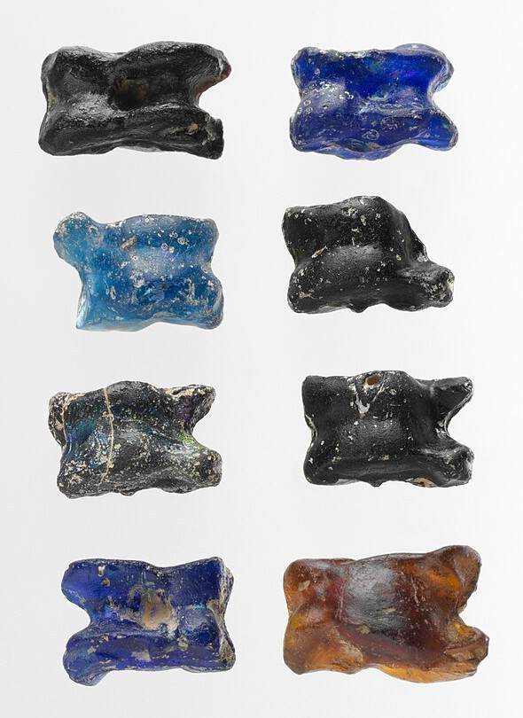

Aleatoric comes from Latin alea: dice. The first dice were ankle bones of sheep and goats, astragali, like these glass ones.

Greek, 3rd–2nd c. BC · The Met, CC0

1 / what is a distribution?

MADS-DAV

Before any shapes: what are we describing? Two kinds of uncertainty. Aleatoric: randomness that is part of the process. The word comes from the Latin alea, a die or a game of dice; the oldest dice were knucklebones, the ankle bones of sheep and goats, which land on one of four sides. The ones in the picture are glass copies from Greece, 3rd to 2nd century BC (Metropolitan Museum of Art, public domain). A fair die is the clean case; no amount of information tells you the next roll. Epistemic: things you could know but don't. Your travel time is uncertain partly because you haven't checked the traffic; check it and the uncertainty shrinks. Real data mixes both. A distribution describes whatever is left after you used what you know, which is why a better model, with more information, gives a narrower distribution. Keep this for question five: a model that looks finished may still be missing knowledge.

■ 1 — what is a distribution?

a die, and the flippers of Adelie penguins

## Three rules make something a distribution

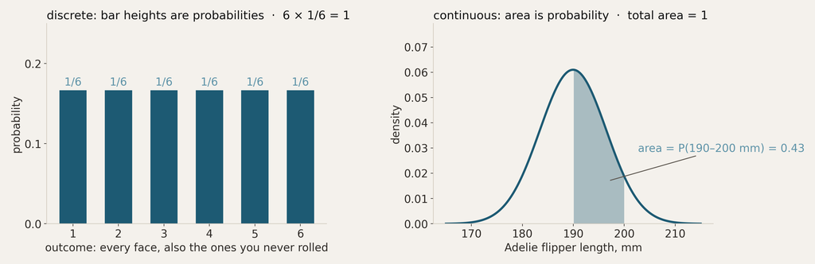

1 · Never negative. No outcome has a probability below zero.

2 · Everything sums to 1. Over all possible outcomes: the bars sum to 1, the area under a curve is 1.

3 · “This or that” adds up. P(1 or 2) = 1/6 + 1/6. For a measurement that sum is an area: a flipper between 190 and 200 mm has probability 0.43.

1 / what is a distribution?

MADS-DAV

The rules, without formulas. One: no probability is negative. Two: over every possible outcome, the probabilities add up to one. Three: the probability of one outcome or another, when they cannot both happen, is the sum. A die is discrete: each bar is a probability. A measurement like flipper length is continuous: there the curve's height is a density, not a probability, and only an area under the curve is a probability. The chance of exactly 190.000 mm is zero; the chance of 190 to 200 mm is the shaded area, 0.43. That is why the y-axis of a curve says density. The next slide makes that concrete.

■ 1 — what is a distribution?

an example: room temperature, mean 21 °C, sd 0.3

## Continuous distributions: there is 0 chance of exactly 21.0 °C

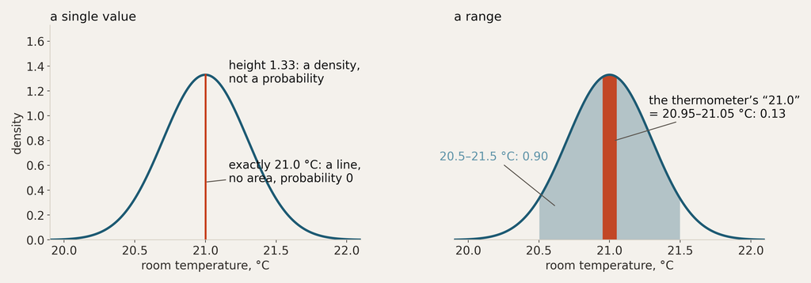

A single value is a line, and a line has no area. A temperature can be 21.0, 21.03, 21.0317 …: each exact value has probability 0.

Ask for a range: 20.5 to 21.5 °C has probability 0.90. Even the thermometer’s “21.0” is a range, 20.95 to 21.05: probability 0.13.

The height of the curve at 21.0 is 1.33. More than 1, so it can’t be a probability: it is a density.

1 / what is a distribution?

MADS-DAV

Rule three, for measurements. Ask "what is the chance that the temperature in this room is 21.0 degrees?" and the honest answer is zero: a temperature can take infinitely many values, and a single value is a line under the curve with no area. What you can ask is a range. Here, as an example, a room whose temperature over the day is a bell with mean 21 and standard deviation 0.3: between 20.5 and 21.5 has probability 0.90. And a thermometer that shows 21.0 is already giving you a range: it rounds, so 21.0 means somewhere between 20.95 and 21.05, probability 0.13. The y-axis shows density, and density can be larger than one: here 1.33 at the peak. That is the quickest proof that the height of a curve is not a probability. For a count, like a die or messages per day, single values do have a probability: those are bars.

■ 1 — what is a distribution?

ten rolls of a fair die

## Same rolls, two plots: only one is a distribution

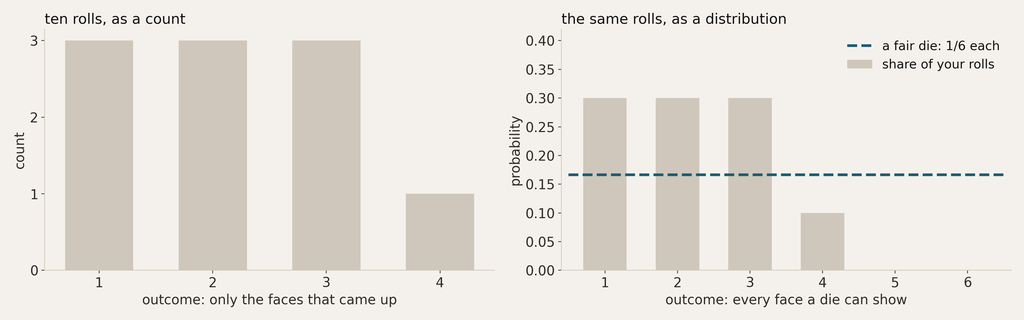

Bars or a line don’t make a plot a distribution. The three rules do.

1 / what is a distribution?

MADS-DAV

Ten rolls of a fair die; by chance no 5 and no 6. The left plot is what you get from value_counts and a bar chart, and it is the plot I get handed most often. It is a description of ten rolls, not of the die: the axis silently drops the faces that didn't come up, and the counts only mean something if you know there were ten. The right plot follows the rules: every outcome the process can produce is on the x-axis, including the ones with zero, and the y-axis holds shares that add up to one. Only then can you compare it with a model, here 1/6 per face, or with a second sample of a different size. Whether you draw bars or a line is a style choice; it is the rules that make it a distribution. Sometimes you do want counts, but then say so in the axis label and don't call it a distribution.

■ 1 — what is a distribution?

leaves falling from a tree, counted per minute

## Start from what you know about the process

what kind of number?

A count

How many leaves fall in one minute: 0, 1, 2, 3 … Never −1, never 2.5.

independent?

Yes

Each leaf falls on its own; one leaf doesn’t pull another down.

steady rate?

On a calm day

About the same number every minute, give or take chance.

model

Poisson

One number describes it: the average per minute.

When the wind picks up, the rate isn’t steady any more. Then the counts spread out far more than Poisson allows, and you need another family.

1 / what is a distribution?

MADS-DAV

The skill for today in one example. Stand under a tree and count how many leaves fall in each minute. You cannot predict which leaf falls when, but you know things about the process, and each of them narrows the choice. It is a count, so a discrete family with whole numbers from zero up. The leaves fall independently. On a calm day the rate is steady. Those three facts together are exactly the assumptions of the Poisson, and then one number, the average per minute, describes the whole distribution. The interesting part is when an assumption breaks: gusts of wind make the rate wander, and the counts spread out more than a Poisson allows. You will see that in chat data in part two.

■ 1 — what is a distribution?

six families, drawn from known parameters

## Six shapes, six ways numbers come about

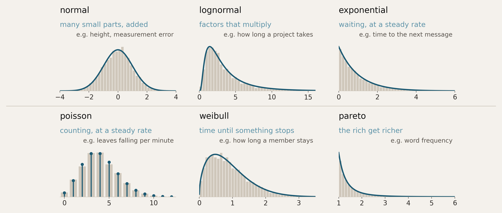

Each panel: a family, the process that produces it, and an example. Drawn from known parameters, so only the shape matters.

Poisson and exponential both need a steady rate. Put rush hour and a quiet afternoon in one column and neither fits.

1 / what is a distribution?

MADS-DAV

The vocabulary for today. Remember the one-liners, not the formulas. Normal: many small parts added up, like height. Lognormal: factors that multiply, like the duration of a project, where every delay stretches what comes after. Exponential: the wait for the next event when events arrive at a steady rate. Poisson: the number of events in a window, again at a steady rate. Weibull: time until something stops, when the chance of stopping changes with age. Pareto: the rich get richer. The steady rate is the assumption people forget: arrivals at a station over a whole day mix rush hour with the quiet early afternoon, and then the exponential no longer fits the waiting times. Poisson is the only count here, so its bars are probabilities; the others are curves where area is probability. In goad you fit a count with discrete=True.

■ 1 — what is a distribution?

20,000 draws per panel

## Adding makes a bell; multiplying makes a long tail

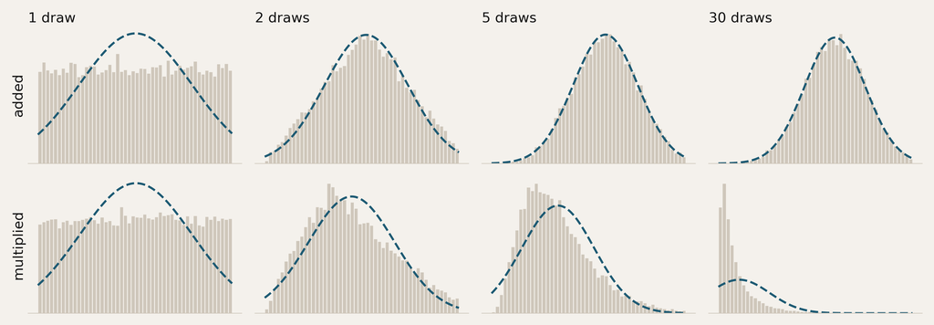

Adding: roll 30 dice and add them up. Human length is the sum of 100+ genes controling the length of a femur, neck, etc. Many small things added up: that is where the normal comes from.

Multiplying: eg a project. Task a takes 1.5 times as long and has to be done ten times, so the impact is 10x1.5. Each delay stretches everything after it: a long right tail.

1 / what is a distribution?

MADS-DAV

This is the central limit theorem without the formula. Top row: add flat random numbers. Two make a triangle, five already look like a bell, thirty are a bell. Thirty dice added up behave the same way: each die is flat, the total is a bell. Bottom row: multiply instead. Every factor makes the result more lopsided, with a long tail to the right. Projects work like that: a delay doesn't add a fixed week, it stretches everything that depends on it. One trick to remember: the log of a product is a sum of logs. So if something is made by multiplying, its log is made by adding, and the log looks like a bell.

■ 1 — what is a distribution?

real data · 10,100 software tasks

## Project planning: delays multiply

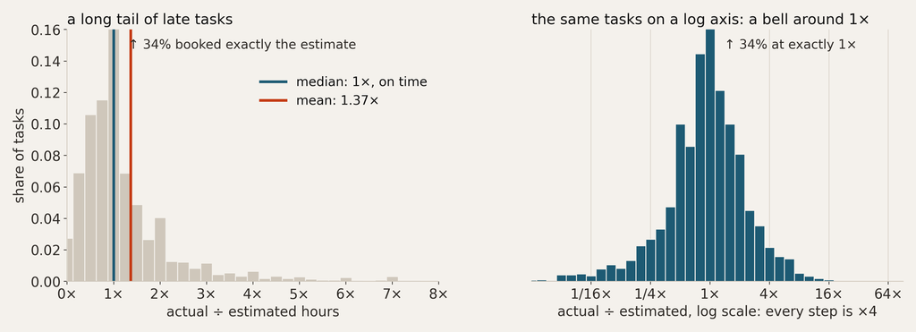

10,100 tasks at one software company over ten years, each with estimated and actual hours. Plotted: actual ÷ estimated.

The median task is exactly on time. Yet the average takes 1.37×, one in ten more than twice as long, one in a hundred more than 7×. The worst: 281×.

On a log axis: a bell around 1×. Half as long (13%) is about as common as twice as long (10%). Even steps in factors: the signature of multiplying.

1 / what is a distribution?

data: github.com/Derek-Jones/SiP_dataset · Jones & Cullum 2019 · CC BY-NC-ND 4.0

Everyone knows projects run late more often than planned. Here is real data: the SiP dataset, 10,100 tasks from ten years of commercial software development at Software in Partnership Ltd, published by Derek Jones and Stephen Cullum (2019, github.com/Derek-Jones/SiP_dataset, CC BY-NC-ND 4.0). For every task the developers estimated the hours, and booked the actual hours. The plot shows actual divided by estimated. The median task is exactly on time, so the estimates are not simply optimistic. But the tail runs one way: the average task takes 1.37 times its estimate, one in ten more than twice, one in a hundred more than seven times, and the worst 281 times. A bell with this mean and standard deviation would put 39 percent of tasks below zero hours. On a log axis the ratios form a rough bell around 1: finishing in half the time (13 percent) is about as common as taking twice as long (10 percent). Symmetric in factors, not in hours: that is what multiplying produces, and it is why a lognormal describes this better than a bell. The spike: 34 percent of tasks booked exactly their estimate, a habit of the people filling in timesheets rather than of the work. Erik Bernhardsson analysed the same data in 'Why software projects take longer than you think' (erikbern.com, 2019); he reports a mean of 1.81 because tasks with several developers appear more than once in the file, counted once here. His later post on sigma-driven project management uses the width of this log-bell to decide when to give up on a project.

● 01 — again, concretely

Dice add up to a bell. Project delays multiply into a long tail. Leaves on a calm day are a Poisson count.

A distribution describes a random process: every possible outcome, with shares that add up to 1.

What you know about the process narrows down the family: a count or a measurement, added or multiplied, a steady rate or not.

Then the data gets to check that choice. That is question two.

Said again, concretely. Three processes, three families, and in each case the family followed from what we knew about how the numbers came about, not from a histogram. A distribution plot has every possible outcome on the x-axis and shares that add up to one on the y-axis. Next: how do you check the choice against real data?

▲ question 02

which distribution fits my data?

## A computer will fit any family to any data. Choosing the family is your job.

1 · Think

Which families make sense for how these numbers came about? Several may fit about equally well; the process decides.

2 · fit

For each family, the fitter finds the parameters that make your data most likely: the mean and sd of a bell, the rate of a Poisson.

3 · check

Do model and data agree, up to chance? Look where they differ, in the tails too. A qq-plot shows you.

A winner that makes no sense for the process is noise, not an answer.

Question two: what is fitting? You can hand a column to a fitter and it will rank every family it knows. That is the worst way to start, because it always returns a winner. Start by thinking: what kind of number is this, how did it come about, which families make sense? Often several fit about equally well, and then what you know about the process decides. Then the fitter does the part computers are good at: for each family, find the parameters under which your data is most probable. That is maximum likelihood. Then check: does the fitted model agree with the data, up to the differences chance makes anyway? Where it doesn't, it usually tells you why. The fit table in goad also gives test scores; with thousands of rows every family gets rejected, so use them to rank, and use your eyes for the rest.

■ 2 — which distribution fits my data?

#ubuntu-it · messages per ordinary thursday

## Messages per day: the rate isn’t steady

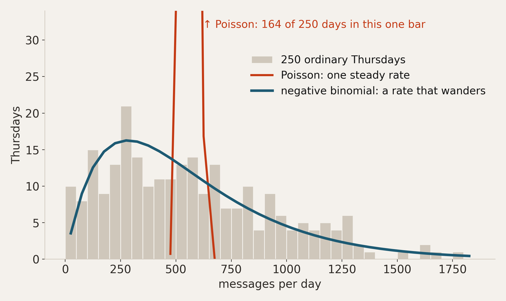

How to read

Bars: 250 ordinary Thursdays in #ubuntu-it, from 10 to almost 1,800 messages; 564 on average.

Red: Poisson, the family for counts at a steady rate. It allows about ±24 messages and squeezes 164 of the 250 days into one bar. Clearly wrong.

Blue: negative binomial, a count whose rate itself changes from day to day. It fits: mean 564, sd 399.

Who is around, what broke, the time of year: they all move the rate. That is the wind from the leaves slide.

2 / which distribution fits my data?

MADS-DAV

Messages per day is a count, so the first candidate is Poisson. Check its assumption first: a steady rate. On a chat channel that is unlikely, and the fit shows it: with a mean of 564 the Poisson allows about 24 messages either way, the channel swings from 10 to 1,800. The negative binomial is a Poisson whose rate is itself drawn anew each day, and it fits. So the honest summary of an ordinary Thursday is not 'about 560 messages' but 'a rate of about 560 that routinely halves or doubles'. The failed Poisson is informative: it tells you the rate moves. Both are fitted with discrete=True, because a count has a probability per whole number.

■ 2 — which distribution fits my data?

palmer penguins · flipper length · 333 birds

## A strange best fit can mean several groups

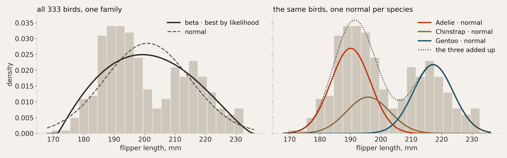

Left: all 333 birds. Two humps. The fitter’s best single curve is a beta: the family for an unknown percentage, like how often a coin lands heads. scipy stretches it over the flipper range. It fits; it means nothing.

Right: one normal per species. Three plain bells, and together they make both humps. The column was never one population: a species has a flipper length, “a penguin” doesn’t.

2 / which distribution fits my data?

MADS-DAV

The most common mistake I see: put the whole column into a fitter and report whatever wins. Here the winner is a beta. A beta describes a percentage you are unsure about: flip a coin ten times, get seven heads, and the beta says which values of 'the chance of heads' are plausible. It is a distribution over a probability, so it lives between zero and one. scipy lets every family shift and stretch with a location and a scale, so it can lay a beta over 170 to 235 millimetres. The fit is real, the meaning is nil: nothing about flipper length is a percentage. A winner like that is a warning. Two humps usually mean two or more groups, and here we know them: three species. Fit one normal per species and each fits fine; Adelie and Chinstrap overlap, Gentoo sits twenty millimetres further. What told us to split was knowing the data, not the fit table.

■ 2 — which distribution fits my data?

penguins · qq-plots against the normal

## A qq-plot shows where model and data disagree

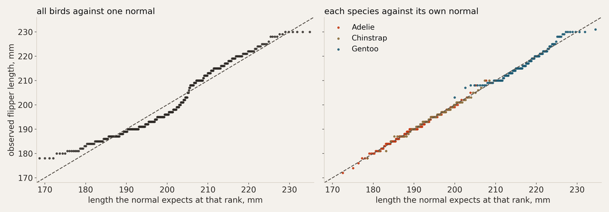

How to read: a boxplot shows three quantiles; a qq-plot shows them all. Each dot is one bird: its real length (y) against what the model expects at that rank (x).

Right: each species against its own normal. The dots follow the line: model and data agree.

2 / which distribution fits my data?

MADS-DAV

The check from the principle slide. You know the boxplot: its box marks three quantiles, the lengths below which a quarter, half and three quarters of the birds fall. A qq-plot does that for every bird. Sort the birds; for each rank, ask the fitted model which length it expects at that rank; plot the real length against it. If the model is right, the dots lie on the diagonal. Left, all birds against one bell: an S-shape, because the pooled data has a dip in the middle where a bell has its peak. Right, each species against its own bell: on the line, apart from the steps that come from measuring to the whole millimetre. The qq-plot is most useful in the tails, where a histogram has too few points to show you anything; we use it on taxi fares in a minute.

● 02 — again, concretely

The fitter crowned a stretched beta. Split by species, and three plain bells appear.

The fitter always returns a winner. Whether that winner makes sense is your call.

Before trying a stranger family, ask whether your column holds several groups.

Then check with a qq-plot: where the dots leave the line, the model is wrong.

Said again. Think about the process, then fit, then check. When the best fit is a family that makes no sense for the data, ask what one row is before you go looking for an even stranger family. Messages per day failed the Poisson because the rate moves; the penguins failed one bell because there were three populations. Both failures told us something about the data.

▲ question 03

what is an outlier?

## Pick the wrong model, and ordinary values look strange.

What does an outlier mean?

1 · A wrong model

The value is ordinary; your distribution doesn’t fit the data, or mixes groups. Fix the model, not the data.

2 · A rare, real value

Unusual but possible: the long ride, the busy day. Keep it; it is often the most interesting row.

3 · An error

A value the process can’t produce: a negative duration, a date in 1970. Remove it, and say that you did.

The boxplot’s whiskers and the “more than three standard deviations” rule both assume a bell. On skewed data, they flag ordinary values.

Question three. An outlier means: the model didn't expect this value. So when you see one, the first suspect is the model. Is the family right, and is this one population? Only then: is it a rare value that really happened, which you keep and which is often the interesting part? Or an error, something the process cannot produce? Statistics can point at the rows to look at. Which of the three it is takes knowledge of the process. And the two rules of thumb everyone knows, the boxplot whiskers and three standard deviations, are both built for a bell. On a long tail they flag perfectly ordinary values.

■ 3 — what is an outlier?

nyc taxis · 6,433 rides · qq-plots

## The bell has no room for expensive rides

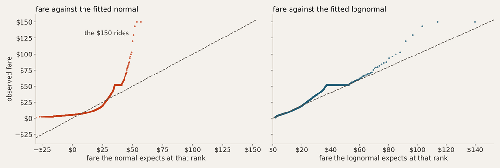

Same reading as the penguins: each dot is one ride, its real fare against the fare the model expects at that rank.

Left: the bell. It expects negative fares at the bottom and about $55 where the real top is $150. Right: a skewed family, the lognormal, follows much further.

Why so skewed? Most rides are short, and for long trips people take cheaper transport. No deep mechanism: we need a family with room on the right.

3 / what is an outlier?

MADS-DAV

Taxi fares, 6,433 New York rides. Mean 13 dollars, median 9.50: the tail pulls the mean up. Against a fitted bell the qq-plot bends away from the line: at the bottom the bell expects negative fares, at the top it has no room for the expensive rides. A right-skewed family follows much further; of the families in goad's list the lognormal fits best. Don't read a mechanism into that. Fares are a base charge plus a meter, so mostly a sum; the skew comes from the trips. Most rides are short, and for long distances people choose a train or a car over a taxi, so long rides are rare. The flat run at 52 dollars is the fixed airport fare, a second process in the same column.

■ 3 — what is an outlier?

taxi fares · the 1.5 × IQR whisker rule

## Outliers, or the wrong model?

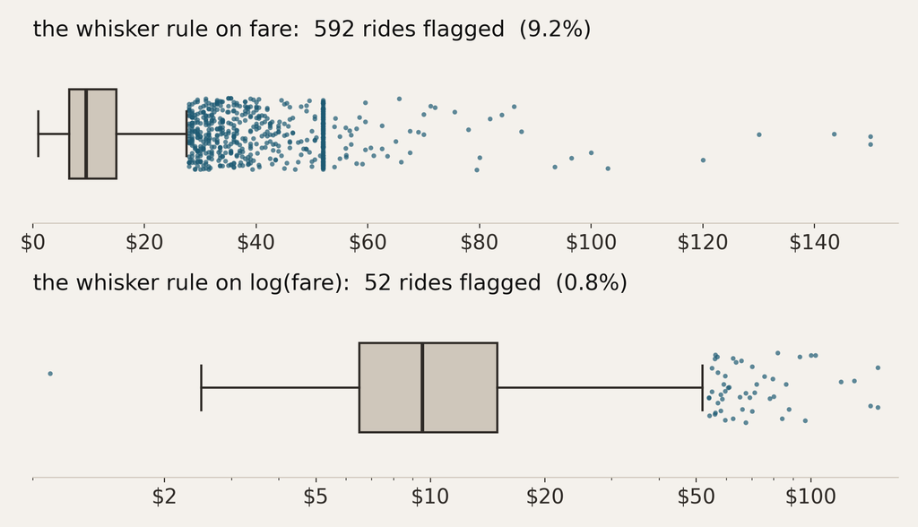

How to read

The whiskers reach 1.5 box-lengths past the box; every point beyond is drawn as an outlier. On a bell, that is 0.7% of the data.

On taxi fares it flags 592 rides: 9.2%. Not 592 strange rides: the bell is the wrong model for fares.

Bottom: the same rule on log(fare) flags 52 rides, 0.8%, about what the rule expects once the shape is close to a bell.

The rule isn’t wrong. It assumes a bell.

3 / what is an outlier?

MADS-DAV

Back to something everyone knows. The boxplot's whiskers reach one and a half box-lengths past the box, and everything beyond is drawn as a dot, usually called an outlier. Tukey designed that for roughly bell-shaped data: on a normal it flags 0.7 percent. On taxi fares it flags 592 rides, 9 percent, including every airport ride. Nothing is wrong with those rides; the model behind the rule is. Apply the same rule to the log of the fare, whose shape is close to a bell, and it flags 52 rides, 0.8 percent. Outlier number one on the principle slide: a wrong model.

■ 3 — what is an outlier?

Tukey’s 1.5 × IQR rule

## The whisker rule makes four assumptions

1 · shape

Roughly symmetric

A bell, not a long tail. On taxi fares the rule flags 592 ordinary rides.

2 · population

One group

Mix groups, and an ordinary member of another group looks like an outlier.

3 · numbers

Continuous

Measurements. Counts, categories and rounded values give ties and steps.

4 · order

Independent

Each value on its own. In a time series, every point depends on the one before.

Break one of these and a dot past the whiskers no longer means “unusual”. Next: an analysis that breaks three.

3 / what is an outlier?

MADS-DAV

Tukey's rule, the dots beyond the boxplot's whiskers, is the outlier definition most people use without knowing they chose one. It quietly assumes four things. One: the data is roughly symmetric, not skewed; we just saw what happens on taxi fares. Two: the data comes from one population; with several groups, what looks like an outlier may be an ordinary member of a different subgroup, as with the penguins. Three: the data is continuous; counts, categories and rounded or discretised values pile up on the same numbers, and the quartiles and whiskers land on awkward ties. Four: the observations are independent; the rule does not know about time, place or groups within groups, so a series where each value builds on the last is out of scope. The same four assumptions hide behind 'more than three standard deviations'.

■ 3 — what is an outlier?

a student analysis · axle load of a garbage truck

## What not to do: judge data without the process

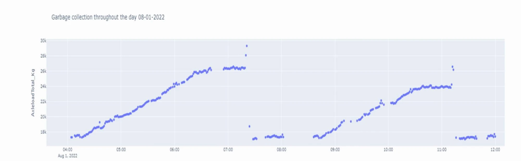

The conclusion: “inconsistent data collection … about 30% of the data is unreliable”, because some days have fewer points.

The process: the load grows along the route, drops when the truck is emptied, and the round starts again. Gaps fit breaks and drives.

Broken: not independent, not one population (full and empty truck), no single distribution over the day. A short day isn’t a bad day.

3 / what is an outlier?

MADS-DAV

A real student analysis from an earlier year, shown as what not to do. The data is the axle load of a garbage truck through one morning. The student saw gaps and uneven numbers of points per day, wrote that this suggests inconsistent data collection, set a threshold of 5,500 points per day, and concluded that about 30 percent of the data is unreliable. Look at the process instead. The load climbs while the truck collects along its route, drops back to roughly the weight of the empty truck when it is emptied, and the next round starts. The flat stretches and gaps fit driving to the dump, waiting and breaks, and the short spikes happen around the emptying itself; whoever runs the trucks can confirm which is which. Now the four assumptions. The points are not independent: every value is the previous load plus what was added. There is not one population: a full truck and an empty truck are different situations. There is no single distribution over the day, so no whisker or density threshold says anything about reliability. And a day with fewer points may simply be a shorter round. None of this data was shown to be unreliable; the analysis never asked how it was made.

■ 3 — what is an outlier?

the most expensive ride in the set: $150

## One $150 ride, three verdicts

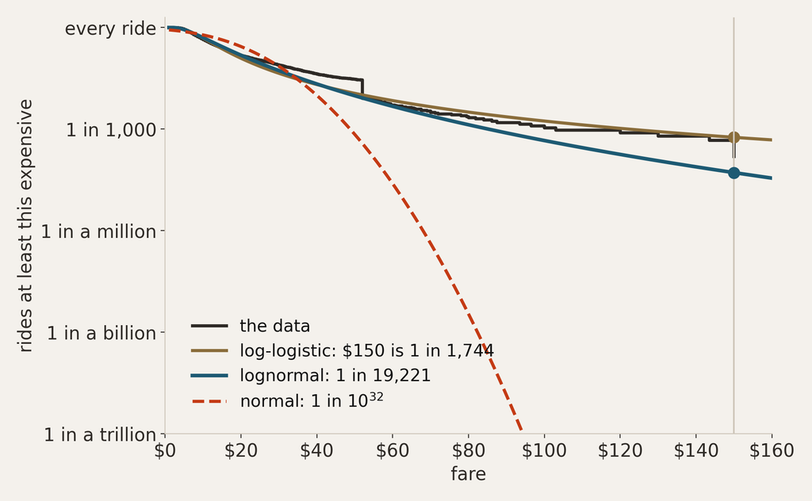

How to read

The share of rides at least this expensive, on a log scale: each step down is 1,000 times rarer. Black is the data.

1 in 10³²

Under the bell: this ride can’t have happened.

1 in 19,000

Under the lognormal, the best of goad’s families.

1 in 1,700

Under the log-logistic, which follows the real tail more closely.

The family decides how rare. Where data is thin, check the tail itself.

3 / what is an outlier?

MADS-DAV

The most expensive ride costs 150 dollars. Is it an outlier? Under the fitted bell it is 11.9 standard deviations above the mean: one in ten to the 32nd, it cannot have happened. Under the lognormal, the best fit among goad's families, it is one in 19,000. Is there a better family? Look at the black line: the real tail is heavier than the lognormal's. The log-logistic, a skewed family outside goad's list, follows it more closely and says one in 1,700. A check in numbers: 7 rides cost 100 dollars or more; the lognormal expects 3, the log-logistic 11. And a warning: the Burr family has a better log-likelihood than both, because it fits the bulk, and expects 32 rides of 150 dollars or more where there are 2. The best fit overall is not the best fit in the tail. Neither verdict says delete the ride; only the bell says it is impossible.

■ 3 — what is an outlier?

penguins · one bird, two populations

## Ordinary among all penguins, rare among her own

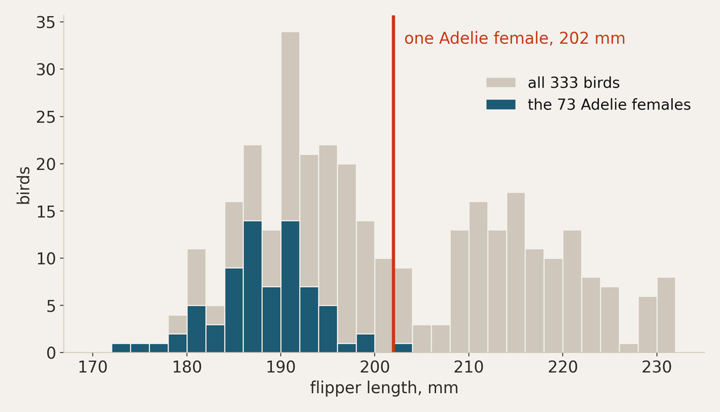

How to read

Grey: all 333 birds. Blue: the 73 Adelie females among them. Red: one Adelie female with a 202 mm flipper.

Among all penguins she stands in the crowd: no rule would flag her. Among Adelie females she is two and a half standard deviations long: 1 in 95.

The reverse happens too: the longest flipper, 231 mm, looks rare pooled (1 in 146) and is an ordinary big Gentoo male (1 in 22).

“Unusual” always means unusual for a population. Pick one that exists.

3 / what is an outlier?

MADS-DAV

One bird, two questions. This Adelie female has a 202 millimetre flipper. Among all penguins she is completely ordinary: she stands in the crowd of another species, and no rule would flag her. Among Adelie females she is two and a half standard deviations long, one in ninety-five. The pooled question is about a population that does not exist. It runs the other way too: the longest flipper looks rare pooled and is an ordinary large Gentoo male. What to do with her is the part the numbers cannot settle: a mis-keyed measurement, a bird whose sex or species was recorded wrongly, or a real large female. Someone who handled the birds knows.

● 03 — again, concretely

A $150 taxi ride is impossible under a bell and merely rare under a skewed family. Same ride, different model.

Before you call something an outlier, check that your distribution fits, in the tails too.

If it fits and the value is still extreme: an error, or a rare real event? That takes knowledge of the process, not statistics.

In your chat: an export glitch, a birthday, the week someone joined.

Said again. The same value can be impossible or ordinary depending on the distribution you hold it against. So the order is: get the model right, including the population, and only then ask about single values. If you remove anything, report how many, on what criterion, and whether your conclusion survives with them left in.

▲ question 04

did something change, or is it chance?

## When the process behind your data changes, its distribution changes with it.

Falling in love

More messages, at other hours, to one person.

A holiday

Fewer messages, and a different rhythm of the day.

A new release

A busier channel, full of questions.

But two samples always differ a little, even from the same process. The question is whether the difference is bigger than chance alone makes.

Question four. A distribution describes a process; when something changes the process, the distribution moves. Someone falls in love and texts more. A holiday changes when and how much people write. A software release brings a crowd of questions. So you compare the distribution before and after. The catch: even if nothing changed, two samples from the same process differ a little, and our eyes are very good at seeing a change in noise. So the question is never 'is there a difference?' but 'is it bigger than the differences chance alone produces?'

■ 4 — did something change, or is it chance?

one person · 74 days of text messages

## Did this person’s texting change?

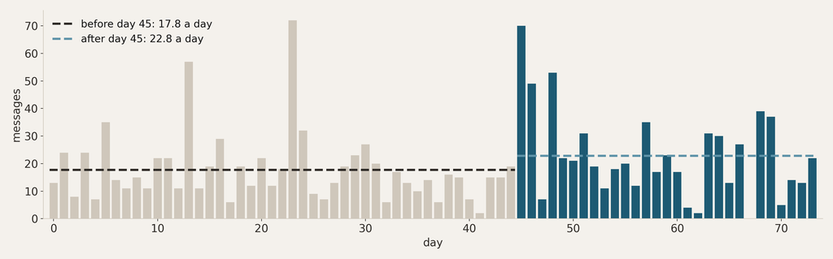

Messages per day for 74 days, the opening example of Cameron Davidson-Pilon’s Bayesian Methods for Hackers. From day 45 on there are more: 22.8 a day instead of 17.8.

But look at single days: 2 one day, 72 another. With this much day-to-day noise, a difference of 5 a day could also be luck. How do you tell?

notebook: [github.com/CamDavidsonPilon/Probabilistic-Programming-and-Bayesian-Methods-for-Hackers](https://github.com/CamDavidsonPilon/Probabilistic-Programming-and-Bayesian-Methods-for-Hackers/blob/master/Chapter1_Introduction/Ch1_Introduction_PyMC2.ipynb)

4 / did something change, or is it chance?

MADS-DAV

The example from the first chapter of Probabilistic Programming and Bayesian Methods for Hackers by Cameron Davidson-Pilon: one person's text messages per day, 74 days. The link goes to the chapter's notebook on GitHub, Chapter1_Introduction, Ch1_Introduction_PyMC2.ipynb. The question in the book: did this person's texting habits change? It looks like it: from around day 45 the average goes from about 18 to about 23. Something might have happened, a new relationship, a new job. But look at the individual days. They jump from 2 to 72. With noise this large, a difference of 5 a day needs checking before you believe it. Next slides: two ways to check, and they disagree.

■ 4 — did something change, or is it chance?

texting · 10,000 shuffles

## Shuffle the labels to see what chance does

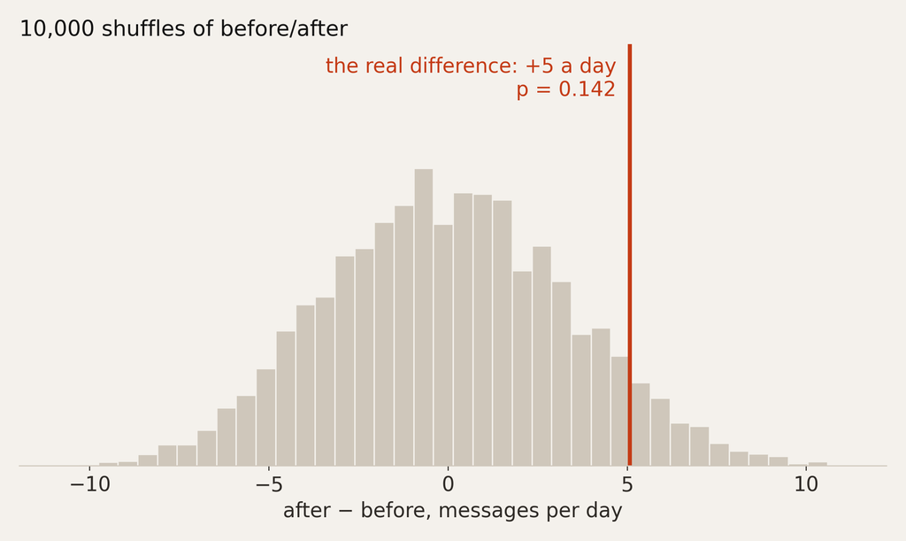

How to read

If day 45 changed nothing, the labels “before” and “after” are arbitrary. So shuffle them over the days, compute the difference again, and repeat 10,000 times.

Grey: the differences chance alone produces. Red: the real one, +5 a day.

14% of the shuffles reach a difference this big (p = 0.14). A change is possible; this alone doesn’t show it.

No formula and no family needed: only the question “what if the label meant nothing?”

4 / did something change, or is it chance?

MADS-DAV

The shuffle, or permutation test. If nothing changed at day 45, then which days we call before and after is arbitrary. So shuffle the labels over the 74 days, keep 45 'before' and 29 'after', compute the difference in means, and do that ten thousand times. That cloud is what chance alone makes. The real difference sits in its upper tail, but one shuffle in seven does as well: a change is possible, not shown. Two remarks. The book's own model is much more confident, because it assumes a Poisson with a steady rate on each side, which allows the days to vary by only about four messages; they vary from 0 to 72. That is the IRC lesson again: the wrong family makes chance look like a change. And day 45 was found by looking at the data. Choosing the split by eye flatters the result; choose your event from the calendar first, then test it.

■ 4 — did something change, or is it chance?

texting · Bayesian Methods for Hackers

## Bayesian Methods for Hackers: a confident switch

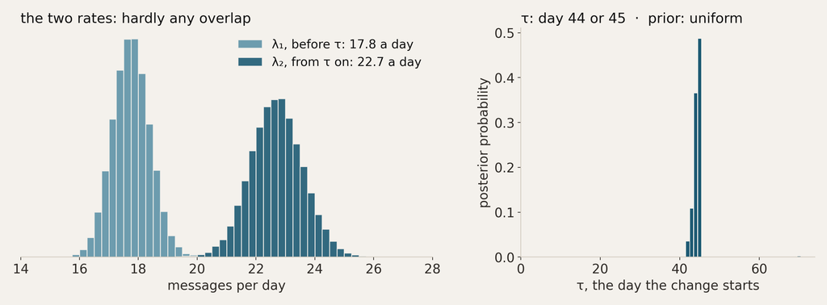

The model: messages per day are Poisson, with rate λ₁ before day τ and λ₂ from τ on. τ gets a discrete uniform prior: each of the 74 days is equally likely to be the switch.

MCMC (Markov chain Monte Carlo) samples which λ₁, λ₂ and τ fit the data. The verdict: from 17.8 to 22.7 a day, from day 44 or 45 on. P(λ₂ > λ₁) = 0.998.

4 / did something change, or is it chance?

MADS-DAV

Bayesian Methods for Hackers answers the same question in a Bayesian way, and comes out confident. The model: the messages on each day are Poisson. Before an unknown day tau the rate is lambda one, from tau on it is lambda two. Tau gets a discrete uniform prior, so every one of the 74 days is equally likely to be the switch before we look at the data, and each lambda gets an exponential prior whose mean is the overall average. MCMC, Markov chain Monte Carlo, explores this model: it draws thousands of combinations of tau and the two rates, in proportion to how well they explain the data. Left, the two rates in one plot: lambda one around 17.8, lambda two around 22.7, and they hardly overlap. Right, tau: day 44 or 45. The probability that the rate went up is 0.998. This small model can be computed exactly, because tau takes only 74 values; that is what is plotted here, and it matches the book's MCMC samples. The shuffle said a difference this size happens in one shuffle out of seven. Same data, very different confidence. Next slide: where that difference comes from.

■ 4 — did something change, or is it chance?

texting · checking the book’s assumption

## Are those assumptions right?

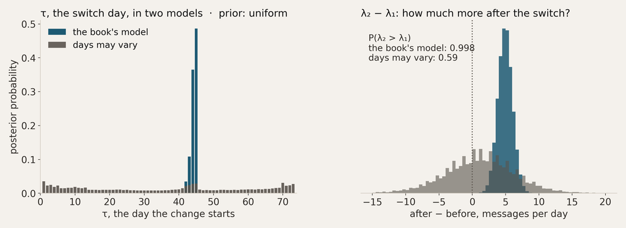

The book’s model gives each period one steady rate: Poisson counts, so a day of about 18 messages varies by ±4. These days run from 0 to 72.

Days may vary: the same model with negative binomial counts. No day stands out as the switch, and P(λ₂ > λ₁) drops to 0.59. With day 45 known in advance: 0.94.

4 / did something change, or is it chance?

MADS-DAV

The book's method is fine; the question is whether its assumptions hold. Both models here keep everything from the book: the uniform prior on tau, the exponential priors on the two rates. The only change is how the counts on a single day vary around their rate. In the book that is a Poisson: a day with an average of 18 messages varies by about 4 either way. These days vary from 0 to 72: the variance is around 155 to 250, the mean around 18 to 23. The data support the second model overwhelmingly: its evidence is about e to the 199 times larger, and under the Poisson you would expect about 0.01 days outside 5 to 40 messages where there are 10. Because the Poisson underestimates the day-to-day noise, it is far too sure about each rate: the spread of its estimate of lambda one is about 0.6 messages, where the data support about 1.8. That is why the two rates on the previous slide hardly overlap. With days that may vary, the posterior of the switch day goes flat, and the probability that the second period is busier drops from 0.998 to 0.59. If you knew in advance that something happened on day 45, say from a calendar, it is 0.94: a likely increase, not a certain one. The next slide shows why knowing the day matters so much.

■ 4 — did something change, or is it chance?

texting · a known day or a searched day

## Searching for the day costs you the evidence

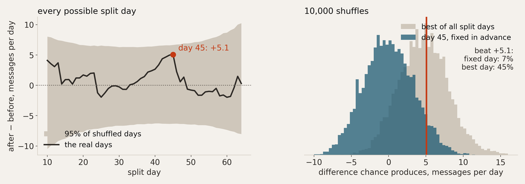

Day known in advance: something happened on day 45. One question: is it busier after? Shuffle: 7%. Model with varying days: 0.94.

Day searched in the data: try every split, keep the biggest difference. Chance gets 55 tries, and its best beats +5 in 45% of shuffles. Model: 0.59.

Day 45 looks special because it was picked for looking special. An event you know beforehand turns 55 questions into one.

4 / did something change, or is it chance?

MADS-DAV

This is the most important slide of the Bayesian detour. There are two different questions hiding in "did the texting change?". One: something happened on day 45, a new relationship, a new job, and I want to know whether the texting went up after it. That is one comparison. The shuffle says a difference of +5 or more turns up in 7 percent of shuffles, and the model in which days may vary gives 0.94 that it went up. Two: I don't know when anything happened, so I look for the day where before and after differ most. Then chance gets a try at every possible split; here 55 of them, with at least ten days on each side. The left panel shows the difference for every split: the real days peak at day 45, but the grey band shows that shuffled days wander just as far. The right panel compares the two questions: grey is the biggest difference chance finds when it may pick the day, petrol the difference at a day fixed in advance. Plus 5 is unusual for one fixed day, and ordinary for the best of 55: it is beaten in 45 percent of shuffles. The Bayesian model does the same bookkeeping automatically: with tau unknown, it has to spread its belief over all days, and with realistic day-to-day noise no day stands out, so P drops to 0.59. With Poisson counts the data look so decisive that this cost disappears, which is why the book could find the day and be sure at the same time. The lesson for your own chat: name the event before you look. Searching first and testing afterwards finds a switch in almost any series.

■ 4 — did something change, or is it chance?

ubuntu irc · release days vs ordinary thursdays

## Same lift, two verdicts

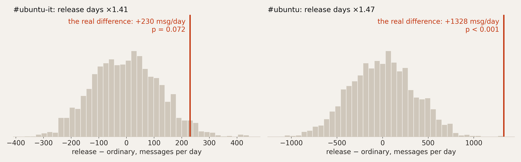

Release days against ordinary Thursdays, the labels shuffled 2,000 times, as in notebook 04.4.

#ubuntu-it: release days are 41% busier, but the real difference sits at the edge of the cloud: p = 0.07. Ten days of a rate that wanders this much can’t settle it.

#ubuntu: 47% busier, and far outside anything the shuffles make (p < 0.001). Its ordinary days are steadier, so the same lift stands out.

4 / did something change, or is it chance?

MADS-DAV

The same test on last week's Ubuntu channels. Is a release day busier than an ordinary Thursday? In both channels it is, by about one and a half times. In the Italian channel the real difference sits at the edge of the shuffle cloud: a two-sided p of 0.07. In the big channel it is far outside anything a shuffle produces. Same effect, different evidence, and the reason is the spread of the ordinary days: in #ubuntu-it they wander by two thirds of their mean, in #ubuntu by a third, because many people averaging out make days more alike. There is no sharp line between chance and change: the further outside the cloud, the more convincing.

● 04 — again, concretely

A 40% busier release day is borderline in a small channel and unmistakable in a big one. The noise decides.

Compare before and after, then ask how big a difference chance alone makes.

Shuffling the labels answers that without assuming a family.

The noisier the ordinary days, the more event days you need before you can see a change.

Said again. A change in the process shows up as a change in the distribution, but every comparison of two samples shows some difference. Shuffle the labels to see the differences chance makes, and see where the real one falls. And the spread of the ordinary days, which you can see before any event, tells you how big a change you can hope to detect.

▲ question 05

is my model done?

## Look at what your model can’t explain: the residual.

observed

−

model

=

residual

The residual looks like chance

Errors around zero, from a plausible family, no pattern over time. Maybe done. But a cause you never measured looks like chance too; more information could still shrink the spread.

The residual has a pattern

A step, a drift, a bend: the model misses a mechanism. That doesn’t make it useless; whether it is good enough depends on what you need.

Good enough is a goal, not a statistic: on a 50/50 bet, being right 51% of the time makes you rich if you can bet enough times in a row.

Question five. Fit a model, subtract it from the data, and look at what is left: the residual. Two situations. If the residual looks like chance, errors around zero from a family that makes sense and no pattern over time, you may be done. May: an influence you never measured also looks like chance, and adding it could still make the spread much smaller. That is the epistemic part from the start of the lesson. If the residual has a pattern, the model is missing a mechanism, and when the pattern starts is often the finding. That does not make the model useless. Whether a model is good enough is a question about your goal: if you bet on something that is 50/50, being right 51 percent of the time is enough to get rich.

■ 5 — is my model done?

dutch covid · 13 oct 2020 – 5 jan 2021 · 85 days

## Before vaccination, the residual looks like chance

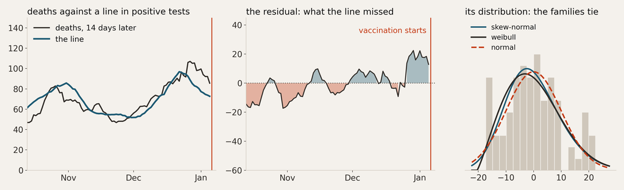

Left: deaths two weeks later against a straight line in positive tests: deaths ≈ 0.0065 × tests + 20.

Middle: what the line missed. Waves around zero, no drift; the last week runs high at the winter peak.

Right: its distribution. Six families within a few points of each other, none rejected. Errors the data can’t tell apart: that is what chance looks like.

5 / is my model done?

MADS-DAV

Public Dutch COVID figures, deliberately not chat data: the loop is what transfers. A pipeline prepared them: daily deaths from the cumulative count, shifted fourteen days back next to the tests that led to them, and a seven-day average against the weekly reporting rhythm. The model: deaths two weeks later are a fixed fraction of positive tests, a straight line. On the window before vaccination started, 6 January, the residual wanders around zero with no drift. The fit table: half a dozen families within a few log-likelihood points of each other, none rejected. The data cannot tell them apart, and that is what chance looks like. The likelihood winner is a bounded beta whose walls sit just outside the most extreme residuals; one more reason not to read the fourth decimal.

■ 5 — is my model done?

dutch covid · oct 2020 – jun 2021 · 232 days

## The residual reveals what the model missed

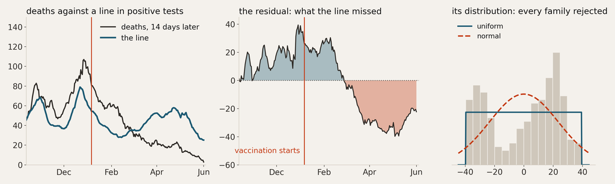

Left: the same kind of line on all 232 days. From March it predicts more deaths than happen, month after month.

Middle: positive through the winter, then negative from 27 February to the end.

Right: every family rejected. The same number of positive tests comes with fewer deaths after the vaccine, so the correlation looks weak but is actually two different random processes.

5 / is my model done?

MADS-DAV

Now the same kind of line on all 232 days. Nothing in it knows that a vaccine exists. The residual changes character: positive through the winter wave, then from late February a long negative run that never comes back. No family fits; the best is uniform, which is what a fitter says when the errors lie along a trend instead of around zero. The residual is pointing at a process the model left out, and roughly when it started: after vaccination, the same number of positive tests comes with fewer deaths. Note what it does not do: it dates the change, it does not prove the cause. Better treatment or a change in who got tested could leave a similar run.

● 05 — again, concretely

After vaccination, the same number of positive tests came with fewer deaths.

Before vaccination, the line was a fine model: what it missed looked like chance.

Over the full window, the residual has a run: a mechanism is missing, here vaccination.

Said again. One straight line, two windows. On the early window the residual looks like chance, and for many purposes the line is good enough. On the full window the residual has a pattern with a start date, and that pattern is the most informative thing the model produced. Next week, notebook 05.3 hands you this residual and asks you to write the missing mechanism into the model.

What is a distribution?

A model of what you can predict about randomness

Which distribution fits my data?

First reason about a model that fits the underlying process before you start fitting.

What is an outlier?

It shows what you modeled as "expected"

Did something change, or is it chance?

Only if the difference is bigger than chance alone makes.

Is my model done?

Study the residual, and wonder what patterns are not picked up.

Lesson 4 · Distributions

The five questions from the start, now with their answers. Notebooks 04.1 to 04.5 work through each of them, ending on your own chat.

← → or click to move · F full screen · N speaker notes